# CGM data LSTM

# lstm prediction

We can `build a LSTM model` using the `keras_model_sequential` function and adding layers on top of that. The `first LSTM layer` takes the `required input shape`, which is the `[samples, timesteps, features]`. We set for both layers return_sequences = TRUE and stateful = TRUE. The last layer is the same with the exception of batch_input_shape, which only needs to be specified in the first layer.

```r
lstm_model <- keras_model_sequential()
```

[output not shown]

```r
lstm_model %>%
  layer_lstm(units = 50, # size of the layer
       batch_input_shape = c(1, 12, 1), # batch size, timesteps, features
       return_sequences = TRUE,
       stateful = TRUE) %>%
  # fraction of the units to drop for the linear transformation of the inputs
  layer_dropout(rate = 0.5) %>%
  layer_lstm(units = 50,
        return_sequences = TRUE,
        stateful = TRUE) %>%
  layer_dropout(rate = 0.5) %>%
  time_distributed(keras::layer_dense(units = 1))
```

[output not shown]

You can also decide to try out different `activation functions` with activation parameter (hyperbolic tangent `tanh is the default one`).

Also `choose loss function for the optimization`, type of optimizer and metric for assessing the model performance. Info about different optimizers can he found here.

```r
lstm_model %>%
    compile(loss = 'mae', optimizer = 'adam', metrics = 'accuracy')

summary(lstm_model)
```

```
Model: "sequential"
_________________________________________________________________________________________________________________________________________________________
Layer (type)                                                        Output Shape                                                  Param #
=========================================================================================================================================================
lstm (LSTM)                                                         (1, 12, 50)                                                   10400
_________________________________________________________________________________________________________________________________________________________
dropout (Dropout)                                                   (1, 12, 50)                                                   0
_________________________________________________________________________________________________________________________________________________________
lstm_1 (LSTM)                                                       (1, 12, 50)                                                   20200
_________________________________________________________________________________________________________________________________________________________
dropout_1 (Dropout)                                                 (1, 12, 50)                                                   0
_________________________________________________________________________________________________________________________________________________________
time_distributed (TimeDistributed)                                  (1, 12, 1)                                                    51
=========================================================================================================================================================
Total params: 30,651
Trainable params: 30,651
Non-trainable params: 0
_________________________________________________________________________________________________________________________________________________________
```

Next, we can`fit our stateful LSTM`. We set `shuffle = FALSE to preserve sequences of time series`.

```r
lstm_model %>% fit(
    x = x_train_arr,
    y = y_train_arr,
    batch_size = 1,
    epochs = 20,
    verbose = 0,
    shuffle = FALSE
)
```

# Perform the prediction

```r
lstm_forecast <- lstm_model %>%
    predict(x_pred_arr, batch_size = 1) %>%
    .[, , 1]

# we need to rescale the data to restore the original values
lstm_forecast <- lstm_forecast * scale_factors[2] + scale_factors[1]
```

# Forecast object

As we have the values predicted, we can turn the results into the `forecast object`, as we would get if using the forecast package. That will allow i.e. to use the forecast::autoplot function to plot the results of the prediction. In order to do so, we need to define several objects that build a forecast object.

# Prediction on train set

```r
 fitted <- predict(lstm_model, x_train_arr, batch_size = 1) %>%
     .[, , 1]
```

Prediction on a training set will provide us with 12 results for each input period. So we need to transform the data to get only one prediction per each date.

```r
if (dim(fitted)[2] > 1) {
    fit <- c(fitted[, 1], fitted[dim(fitted)[1], 2:dim(fitted)[2]])
} else {
    fit <- fitted[, 1]
}

# additionally we need to rescale the data
fitted <- fit * scale_factors[2] + scale_factors[1]
nrow(fitted) # 562
```

Due to the fact that our forecast starts with 12 months offset, we need to provide artificial (or real) values for those months:

```r
# I specify first forecast values as not available
fitted <- c(rep(NA, lag), fitted)
```

# prediction in a form of ts object

```r
lstm_forecast <- timetk::tk_ts(lstm_forecast,
    start = c(2015, 5),
    end = c(2016, 4),
    frequency = 12)
```

# input series

Additionally we need to transform the economics data into a time series object.

```r
input_ts <- timetk::tk_ts(economics$unemploy,
    start = c(1967, 7),
    end = c(2015, 4),
    frequency = 12)
```

#forecast object Finally we can `define the forecast object`:

```r
forecast_list <- list(
    model = NULL,
    method = "LSTM",
    mean = lstm_forecast,
    x = input_ts,
    fitted = fitted,
    residuals = as.numeric(input_ts) - as.numeric(fitted)
  )

class(forecast_list) <- "forecast"
```

Now we can easily `plot the data`:

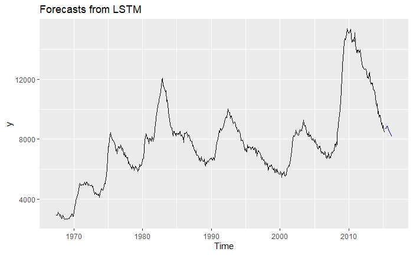

```r
forecast::autoplot(forecast_list)
```